# Los Angeles airport passenger prediction with Box Jenkins

### Out of sample analysis

Let’s confirm our model with an out-of-sample analysis.  
In order to do that, we will split our Lax data into two samples : one train dataset and a test dataset.

We will re-run our model on train datasets, forecast results and use accuracy analysis which will compare forecast results and test dataset in order to identify the best accuracy of model. We will use the forecast library to forecast models.

```r
library(forecast)
```

Split train and test lax dataset.

```r
train.traf <- window(traf,start=2006,end=2017)
test.traf <- window(traf,start=2018,end=2019)
```

Log transformation

```r
train.ltraf<-train.traf %>% log
test.ltraf<-test.traf %>% log
```

Run our different models on train.ltraf

```r
train.mod1 <- forecast::Arima(train.ltraf, c(2, 1, 1),seasonal = list(order = c(1, 1, 1), period = 12), method='ML')
train.mod2 <- forecast::Arima(train.ltraf, c(0, 1, 1),seasonal = list(order = c(1, 1, 1), period = 12), method='ML')
train.mod3 <- forecast::Arima(train.ltraf, c(0, 1, 1),seasonal = list(order = c(0, 1, 1), period = 12), method='ML')
```

Since we are only interresed here in accuracy, we will not use SARIMAX and dummy variable. But we keep in mind that SARIMAX had better AIC.

Let’s plot the fitted value compared to raw data…

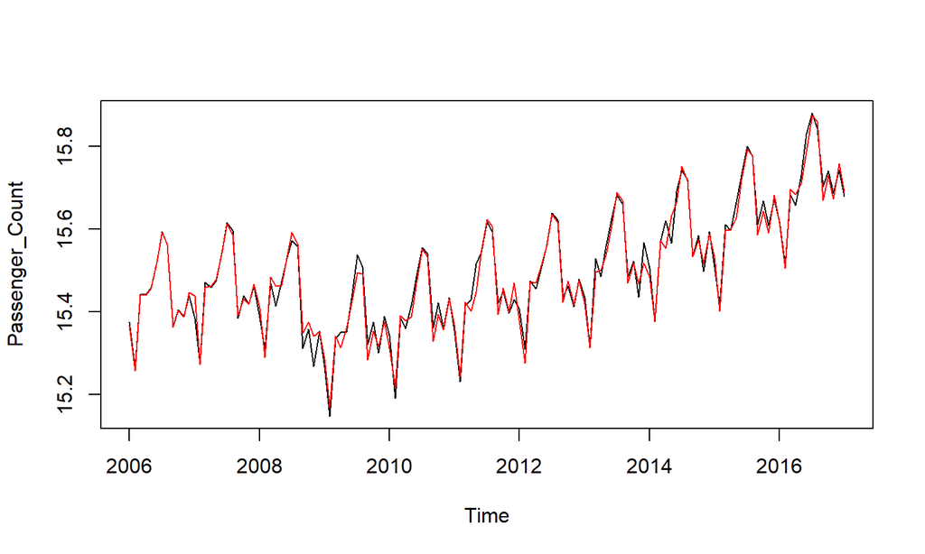

```r
plot(train.ltraf)
lines(fitted(train.mod1), col='red')
```

…and do our first forecast with train dataset.  
We can now plot accuracy of our mod1 by comparing forecast results and test dataset.

```r
tsforecasts1 <- forecast(train.mod1)
```

```r
a1<-accuracy(tsforecasts1,test.ltraf)
a1
```

```
##                        ME       RMSE        MAE         MPE       MAPE
## Training set  0.002665415 0.02182828 0.01564985  0.01695709 0.10103583
## Test set     -0.012314044 0.01864545 0.01443758 -0.07782445 0.09129407
##                   MASE        ACF1 Theil's U
## Training set 0.3062591 -0.01690299        NA
## Test set     0.2825356  0.41918976 0.2209551
```

Mod2

fitted value

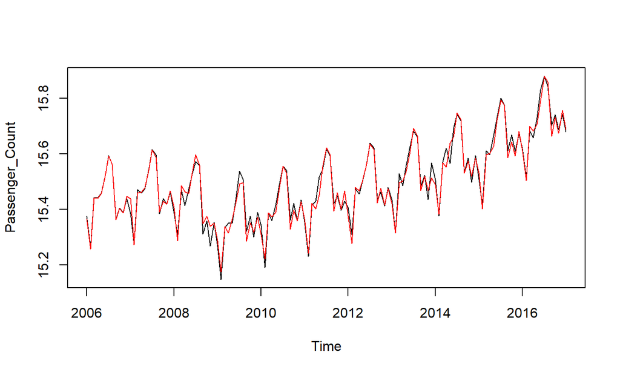

```r
plot(train.ltraf)
lines(fitted(train.mod2), col='red')
```

Forecast and accuracy

```r
tsforecasts2 <- forecast(train.mod2)
a2<-accuracy(tsforecasts2,test.ltraf)
a2
```

```
##                       ME       RMSE        MAE         MPE       MAPE      MASE
## Training set  0.00272312 0.02216916 0.01580817  0.01732124 0.10208006 0.3093574
## Test set     -0.01358437 0.01966256 0.01523886 -0.08586378 0.09635771 0.2982164
##                     ACF1 Theil's U
## Training set -0.07248321        NA
## Test set      0.42861768 0.2328797
```

Mod3 fitted value

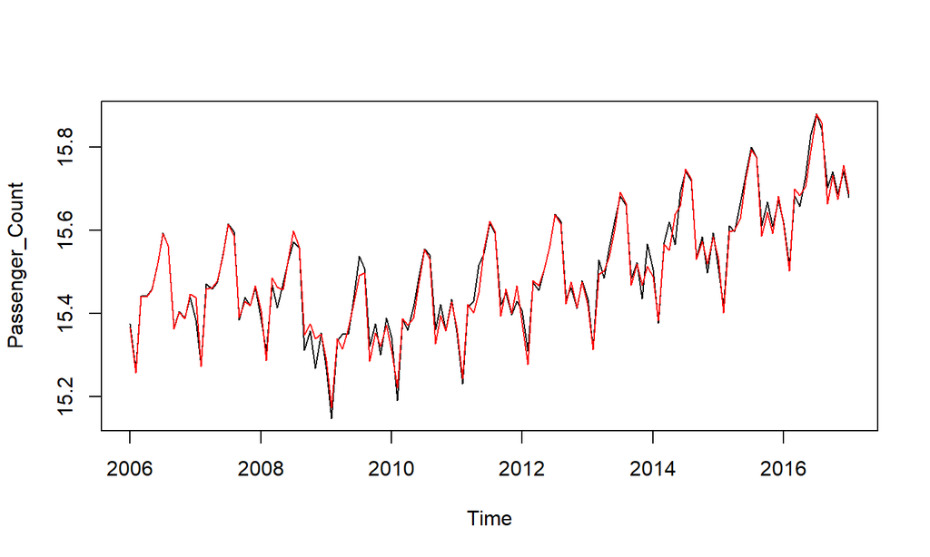

```r
plot(train.ltraf)
lines(fitted(train.mod3), col='red')
```

```r
tsforecasts3 <- forecast(train.mod3)
a3<-accuracy(tsforecasts3,test.ltraf)
a3
```

```
##                        ME       RMSE        MAE         MPE      MAPE      MASE
## Training set  0.002738695 0.02224358 0.01585625  0.01742216 0.1023913 0.3102983
## Test set     -0.017114488 0.02263862 0.01766283 -0.10820970 0.1116790 0.3456521
##                     ACF1 Theil's U
## Training set -0.07211241        NA
## Test set      0.45917165 0.2678647
```

Let’s use performance metrics **Root Mean Squared Error and Mean Absolute Error**. The closer to Zero those 2 metrics are, the better. We can notice that first, all our model have good performance metrics, they are enough close to zero to best called as good model.

What we can notice here is that we have an opposition between AIC conclusion on performance of model and performance metrics conclusion.

Let’s finally pass to our prediction part.

## Prediction

First, we need to supply new values of our regression. Newxreg should indeed be a matrix that contains values of the regressors we want to predict.

```r
trick <- matrix(rep(0, 12), ncol=4)

length(trick)
```

```
## [1] 12
```

```r
mod2
```

```
##
## Call:
## arima(x = ltraf, order = c(0, 1, 1), seasonal = list(order = c(0, 1, 1), period = 12),
##     xreg = cbind(unlist(Lax_data$dum_1), unlist(Lax_data$dum_2), unlist(Lax_data$dum_3),
##         unlist(Lax_data$dum_4)), method = "ML")
##
## Coefficients:
##           ma1     sma1    xreg1   xreg2   xreg3    xreg4
##       -0.3622  -0.6969  -0.0318  0.0445  0.0643  -0.0465
## s.e.   0.0716   0.0792   0.0148  0.0145  0.0154   0.0154
##
## sigma^2 estimated as 0.0003598:  log likelihood = 367.66,  aic = -723.31
```

```r
pred <- predict(mod2, n.ahead = 12, newxreg = trick)
```

Let’s plot our forecast.

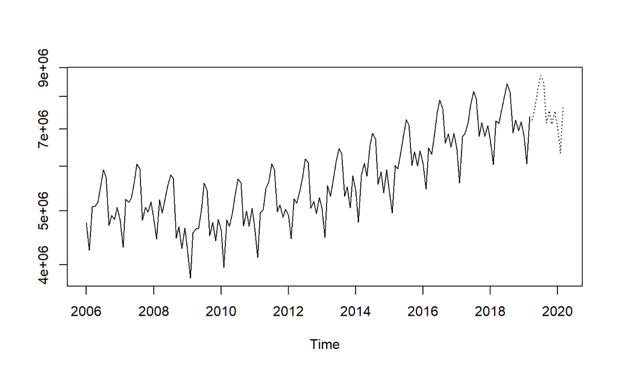

```r
ts.plot(traf,2.718^pred$pred, log = "y", lty = c(1,3))
```

We plot just from 2010.

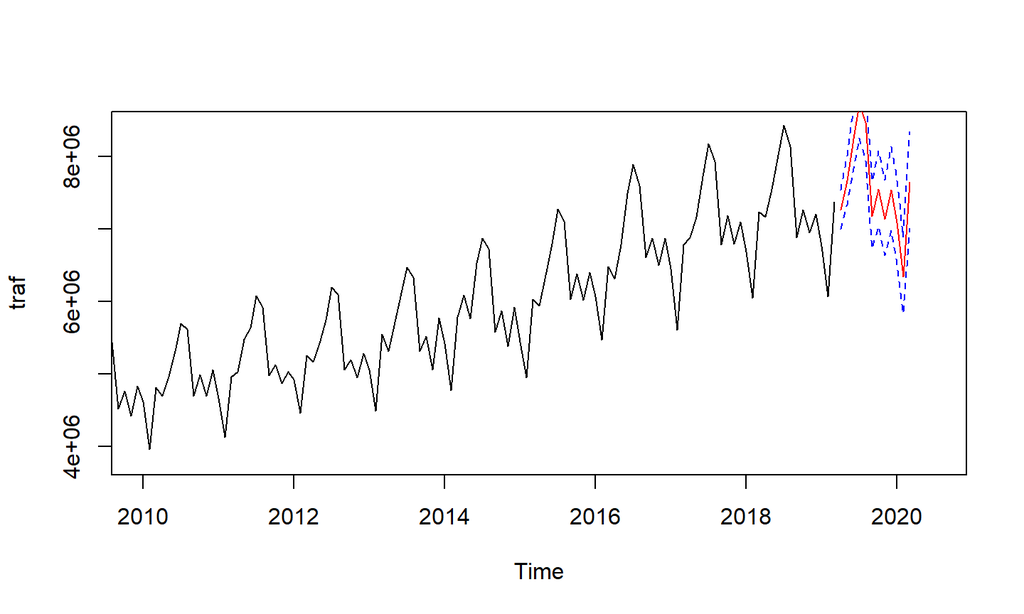

```r
ts.plot(traf,xlim=c(2010,2020.500))
lines(2.718^(pred$pred), col="red")
lines(2.718^(pred$pred-1.96*pred$se),col=4,lty=2)
lines(2.718^(pred$pred+1.96*pred$se),col=4,lty=2)
```

## 5. Conclusion

Using data for LAX passengers we built a **SARIMA** and **SARIMAX** model to predict number of passengers one year ahead.  
We saw that the model suits the testing data pretty well. To see how well our model does, it will be fascinating to track the real number of passengers for the next few months.  
Nonetheless, the model doesn’t take into account external events such as Covid-19 outbreak which dramatically changed the airports traffic.